# Restauration d’image grâce aux chaînes de markov

## L’algorithme de Metropolis

L’algorithme que l’on va principalement utiliser pour la restauration d’image s’appelle l’algorithme de Metropolis.

En R voici une manière de coder cet algorithme :

```r
#algo de Metropolis
#voisinage à la main
#pas de correspondance

metropolisIsing=function(forme, N, beta, B, alpha, n, p){
    #fonction qui réalise l'algorithme de Gibbs sur une image bruitée img1 (à partir de img0),pour restaurer cette image.

    #----création de l'image parfaite img0----
    img0 = imageGenerator(forme, N)

    #----création d'une image auxiliaire img1, avec bord plus long et bruitage----
    img1 = matrix(0, nrow=N+2, ncol=N+2)
    img1[2:(N+1),2:(N+1)] = bruiteur(img0, "rbinom", p)
    img2 = img1 #image tampon
    img3 = img1 #mémoire du bruit initiale

    for(k in 1:n){ #n visites de pixels

        #----choix d'un pixel au hasard----
        i <- 1+ceiling(N*runif(1)) # indice entre 2 et N+1
        j <- 1+ceiling(N*runif(1))

        #----tirage nouvelle valeure candidate----
        img2[i,j] = -img1[i,j]

        #----voisinage----
        v = img1[i+1,j] + img1[i-1,j] + img1[i,j+1] + img1[i,j-1]

        #----potentiels----
        U1 = -B*img1[i,j]-img1[i,j]*(beta*v + alpha*img3[i,j])#potentiel actuel
        U2 = -B*img2[i,j]-img2[i,j]*(beta*v + alpha*img3[i,j])#potentiel candidat

        #----test----
        dU = U2-U1
        p <- exp(-U2)

        if(runif(1)<=p){img1[i,j]= -img1[i,j]}#on change la valeur du pixel
        else{img2[i,j] <- img1[i,j]} #on garde la valeur du pixel
    }#for

    #----affichage----
    img3 <- img3[2:(N+1),2:(N+1)] #on retire le contour
    img1 <- img1[2:(N+1),2:(N+1)]

    par(mfrow=c(1,3))
    image(1:N,1:N,img0)#image initiale
    image(1:N+2,1:N+2,img3)#image bruitée
    image(1:N+2,1:N+2,img1)#image restaurée

}#func
```

> **Le paramètre alpha** détermine l’importance donnée à l’image bruitée initiale dans la probabilité conditionnelle $P(X_s=x_s|V_s)$.  
> - Si alpha est trop grand devant $\beta$, les valeurs les plus probables seront toujours celles de l’image bruitée, et donc l’algorithme ne fera rien.

metropolisIsing avec $\alpha = 5$ et $\beta = 1$

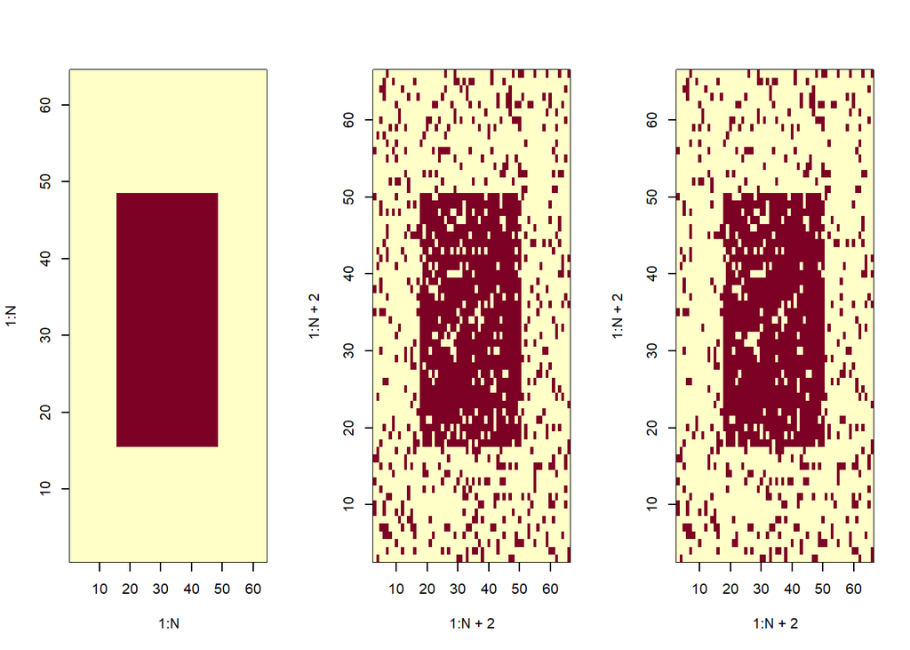

> S’il est trop petit voir nul, la configuration initiale va être oubliée itération après itération, et on va tendre vers l’image blanche, soit donc la configuration d’énergie minimale parmi toutes les configurations possibles.

metropolisIsing avec $\alpha = 0$

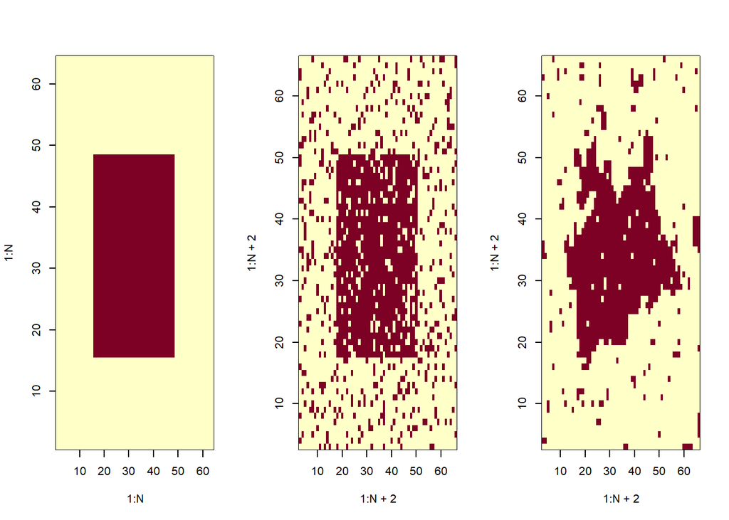

> **Le paramètre $\beta$** quant à lui détermine quel motifs seront les plus probables, entre des pixels de mêmes valeurs ($\beta > 0$) ou bien une alternance de pixel banc et noir ($\beta < 0$).

metropolisIsing avec $\beta > 0$

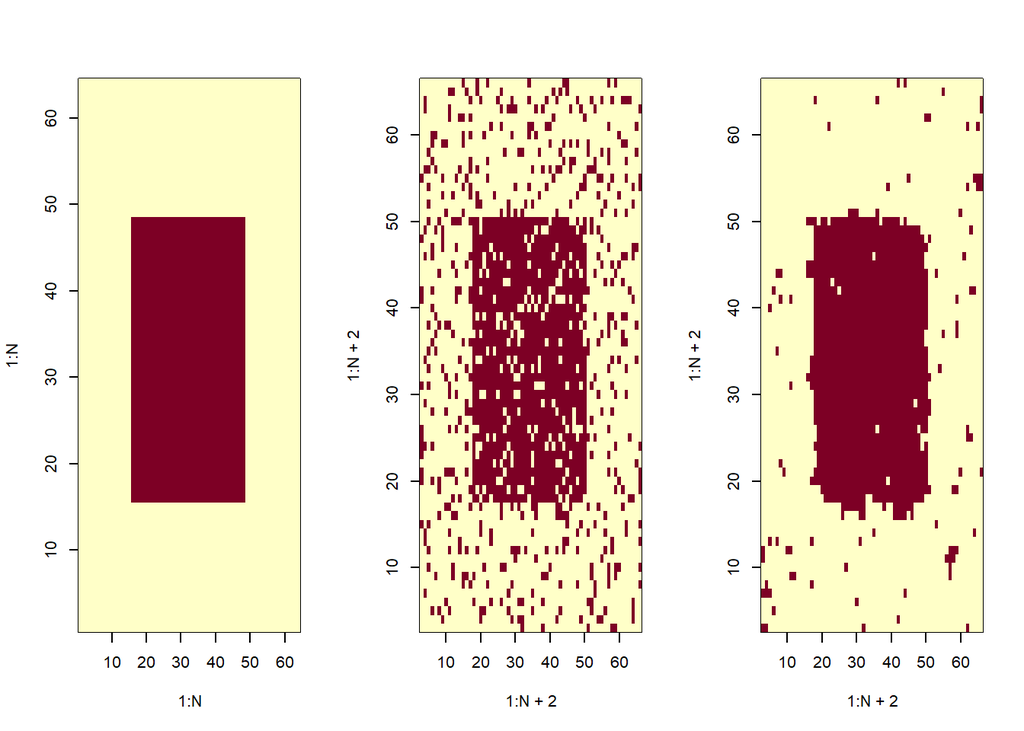

metropolisIsing avec $\beta < 0$

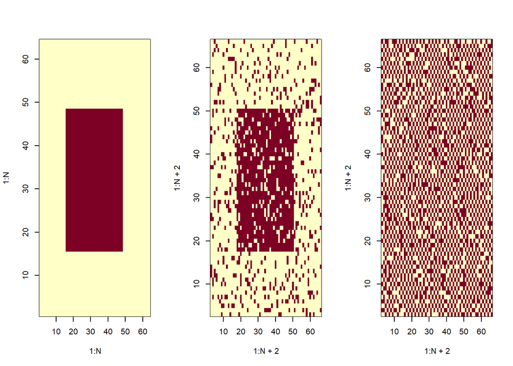

> **Le calcul du voisinage** se fait assez facilement en R, on regarde la valeur des quatre pixels à gauche à droit en haut et en bas du pixel. Plus tard on utilisera la fonction Vstar(), qui permet d’étendre ce voisinage.

> **Le parcours des sites_** peut se faire soit aléatoirement, soit systématiquement (ligne par ligne par exemple).